# Practical Machine Learning Project

### Background

This is the report of the project for practical machine learning course from John Hopkins University. The purpose of this project is to address the following question.

By processing data gathered from accelerometers on the belt, forearm, arm, and dumbell of the participants in a machine learning algorithm, the question is that can the appropriate activity quality (class A-E) be predicted?

Libraries used in this project are first loaded.

```r
libs=c('data.table','caret','dplyr','corrplot','rattle','rpart.plot')
lapply(libs,library,character.only=T)
```

### Data Load and Processing

Data is first imported with proper NA value specified. As the positions of belt, arm, forearm, dumbbell of different people could be different even doing the same activity, the classification should not only have the information of activity class but also users.

```r
setwd('~/Practical Machine Learning/')
test=fread('data/pml-testing.csv',na.strings=c('','#DIV/0!','NA'))
train=fread('data/pml-training.csv',na.strings=c('','#DIV/0!','NA'))
# Combine name and class and convert into factor
train[,UserClass:=as.factor(paste(user_name,classe))]
```

#### Clean and Transform Data

Variables with NA values will be eliminated from the model and all predictors are transformed into numeric data type for further analysis. The training data is split into train set, **75%**, and crossvalidation set, **25%**.

```r
# columns that are has NA
NaCol=train[,sapply(.SD,function(x) any(is.na(x)))]

## Train data
Train_clean=train %>%   # Combine name and class and convert into factor
  names %>%
  grep('belt|arm|forearm|dumbbell',.) %>%         #Get all name indexes of measurement variables
  intersect(.,as.numeric(which(NaCol==F)))  %>%   #Remove the NA variables
  train[,.,with=F] %>%
  sapply(.,as.numeric) %>%                        #Convert all measurement variables into numeric
  data.frame()

Train_clean$UserClass=train$UserClass  #Include the result column

## Test data
Test_clean=test %>%   # Combine name and class and convert into factor
  names %>%
  grep('belt|arm|forearm|dumbbell',.) %>%         #Get all name indexes of measurement variables
  intersect(.,as.numeric(which(NaCol==F)))  %>%   #Remove the NA variables
  test[,.,with=F] %>%
  sapply(.,as.numeric) %>%                        #Convert all measurement variables into numeric
  data.frame()

Test_clean$User=test$user_name
Test_clean$Problem_id=test$problem_id

# Training data split
set.seed(3721)

inTrain = createDataPartition(Train_clean$UserClass, p = 3/4, list=FALSE)
training = Train_clean[inTrain,]
crossValidation = Train_clean[-inTrain,]

ncol(Train_clean)
```

```
## [1] 53
```

After cleaning the NA variables, there remain 52 variables and a user class column.

### Feature Selection

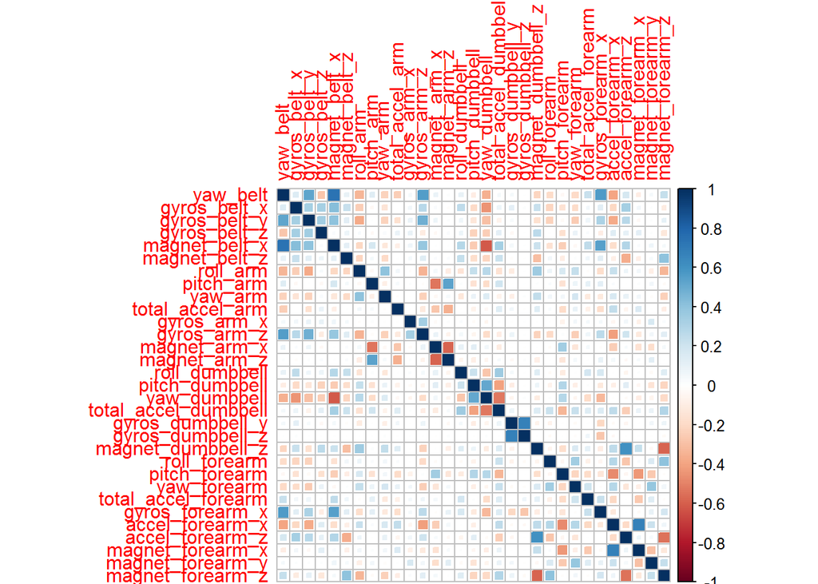

```r
#Detect highly correlated variables
highCor=training[,-grep('UserClass',names(training))] %>%
  scale(.,center=T,scale=T) %>%                   #Standardize values
  cor(.,use= "pairwise.complete.obs") %>%  #Calculate the correlation matrix
  findCorrelation(.,0.75)

#Correlation plot
training[,-c(highCor,grep('UserClass',names(training)))] %>%                #Remove the highly correlated variables
  scale(.,center=T,scale=T) %>%                   #Standardize values
  cor(.,use= "pairwise.complete.obs")  %>%
  corrplot(.,method='square',mar=c(0,0,0,0))
```

```r
training_sim=training[,-highCor]
crossValidation_sim=crossValidation[,-highCor]
Test_clean_sim=Test_clean[,-highCor]

length(highCor)
```

```
## [1] 21
```

After the analysis of variable correlations, 21 variables are removed from modeling for redundency.

### Modeling

A pre-processing is conducted before building the predict model. BoxCox, scale and principle component analysis are used to transform and reduce the variables using training data. This process is then applied to training, crossvalidation and test data sets.

```r
trans = preProcess(training_sim[,-grep('UserClass',names(training_sim))],
                   method=c("BoxCox", "center",
                            "scale", "pca"))

# Get the principle component for training, crossvalidation and test set
train_PC = predict(trans, training_sim[,-grep('UserClass',names(training_sim))])
train_PC$UserClass=training_sim$UserClass

crossValidation_PC = predict(trans, crossValidation_sim[,-grep('UserClass',names(crossValidation_sim))])
crossValidation_PC$UserClass=as.character(crossValidation_sim$UserClass)

test_PC = predict(trans, Test_clean_sim[,1:31])
test_PC$Problem_id=Test_clean_sim$Problem_id
test_PC$User=Test_clean_sim$User
```

#### Decision Tree

The decision tree model only returns 44.4% accuracy.

```r
Dtree <- rpart(UserClass ~ .,
               data=train_PC,
               method="class")


predDtree <- predict(Dtree,
                     crossValidation_PC[,-grep('UserClass',names(crossValidation_PC))],
                     type="class")

confusionMatrix(predDtree, crossValidation_PC$UserClass)$overall
```

```
##       Accuracy          Kappa  AccuracyLower  AccuracyUpper   AccuracyNull
##     0.44401308     0.42245753     0.43002759     0.45806541     0.06007356
## AccuracyPValue  McnemarPValue
##     0.00000000            NaN
```

#### Random Forest

```r
Model=train(UserClass~.,
            data=train_PC,
            method = "rf",
            prox=T,
            ntree=200)
Pred=predict(Model,
             crossValidation_PC[,-grep('UserClass',names(crossValidation_sim))])
confusionMatrix(Pred, crossValidation_PC$UserClass)$overall
```

```
##       Accuracy          Kappa  AccuracyLower  AccuracyUpper   AccuracyNull
##     0.97425419     0.97329193     0.96942191     0.97850879     0.06007356
## AccuracyPValue  McnemarPValue
##     0.00000000            NaN
```

```r
paste('Out-of-sample error:',format(1-confusionMatrix(Pred, crossValidation_PC$UserClass)$overall[1],digits=4))
```

```
## [1] "Out-of-sample error: 0.02575"
```

Random Forests yielded better Results, as expected! The out-of-sample error is 2.5%.

### Predict and Conclusion

The model is then applied to the principle component of the test data to predict the user and class information. A second cross validation is performed on the user information, which returns a 100% accuracy. It can be conclude that the random forest gives an perfect prediction of users and a good prediction on class with a 97.5% accuracy.

```r
predresult <- predict(Model, test_PC[,1:23])
test_PC$Pred=as.character(predresult)
test_PC=data.table(test_PC)
test_PC[,UserPred:=substr(Pred,1,nchar(Pred)-2)]
```

```r
confusionMatrix(test_PC$UserPred, test_PC$User)$overall
```

```
##       Accuracy          Kappa  AccuracyLower  AccuracyUpper   AccuracyNull
##   1.000000e+00   1.000000e+00   8.315665e-01   1.000000e+00   4.000000e-01
## AccuracyPValue  McnemarPValue
##   1.099512e-08            NaN
```

### Generate Files for submission

```r
pml_write_files = function(x){
  n = length(x)
  for(i in 1:n){
    filename = paste0("problem_id_",i,".txt")
    write.table(x[i],file=filename,quote=FALSE,row.names=FALSE,col.names=FALSE)
  }
}

predresult %>%
      data.frame(class=as.character(.)) %>%
      apply(.,1,function(x) substr(x,nchar(x),nchar(x))) %>%
      pml_write_files(.)
```